# PracticalMachineLearning -Course project-

OscarAMtz

13/4/2020

```r
knitr::opts_chunk$set(cache = TRUE)
```

## Background for this tutorial

The use of devices for activity monitoring is widely accepted among people and nowadays is possible to collect a large amount of data about personal activity relatively inexpensively. These type of devices are part of the quantified self movement – a group of enthusiasts who take measurements about themselves regularly to improve their health, to find patterns in their behavior, or because they are tech geeks. One thing that people regularly do is quantify how much of a particular activity they do, but they rarely quantify how well they do it. In this tutorial we will be able to use data from accelerometers on the belt, forearm, arm, and dumbell of 6 participants. They were asked to perform barbell lifts correctly and incorrectly in 5 different ways. More information is available from the [website](http://groupware.les.inf.puc-rio.br/har)

## Data

The data used for this proyect can be found here:

[Training](https://d396qusza40orc.cloudfront.net/predmachlearn/pml-training.csv)

[Testing](https://d396qusza40orc.cloudfront.net/predmachlearn/pml-testing.csv)

[More info](http://groupware.les.inf.puc-rio.br/har)

Downloading the data

```r
TrainingDT <- tidyr::as_tibble(read.csv(url("https://d396qusza40orc.cloudfront.net/predmachlearn/pml-training.csv")))
TestingDT <- tidyr::as_tibble(read.csv(url("https://d396qusza40orc.cloudfront.net/predmachlearn/pml-testing.csv")))
```

## Database description

The resulting model will be tested in the pml_testing file and by exploring this file we can identify that there are variables without variation and with the absence of data, these variables will not be useful when predicting the type of movement given the value of the independent variables.

```r
# Testing dimensions
dim(TestingDT)
```

```
## [1]  20 160
```

```r
head(TestingDT, 5)
```

```
## # A tibble: 5 x 160
##       X user_name raw_timestamp_p~ raw_timestamp_p~ cvtd_timestamp new_window
##   <int> <fct>                <int>            <int> <fct>          <fct>
## 1     1 pedro           1323095002           868349 05/12/2011 14~ no
## 2     2 jeremy          1322673067           778725 30/11/2011 17~ no
## 3     3 jeremy          1322673075           342967 30/11/2011 17~ no
## 4     4 adelmo          1322832789           560311 02/12/2011 13~ no
## 5     5 eurico          1322489635           814776 28/11/2011 14~ no
## # ... with 154 more variables: num_window <int>, roll_belt <dbl>,
## #   pitch_belt <dbl>, yaw_belt <dbl>, total_accel_belt <int>,
## #   kurtosis_roll_belt <lgl>, kurtosis_picth_belt <lgl>,
## #   kurtosis_yaw_belt <lgl>, skewness_roll_belt <lgl>,
## #   skewness_roll_belt.1 <lgl>, skewness_yaw_belt <lgl>, max_roll_belt <lgl>,
## #   max_picth_belt <lgl>, max_yaw_belt <lgl>, min_roll_belt <lgl>,
## #   min_pitch_belt <lgl>, min_yaw_belt <lgl>, amplitude_roll_belt <lgl>,
## #   amplitude_pitch_belt <lgl>, amplitude_yaw_belt <lgl>,
## #   var_total_accel_belt <lgl>, avg_roll_belt <lgl>, stddev_roll_belt <lgl>,
## #   var_roll_belt <lgl>, avg_pitch_belt <lgl>, stddev_pitch_belt <lgl>,
## #   var_pitch_belt <lgl>, avg_yaw_belt <lgl>, stddev_yaw_belt <lgl>,
## #   var_yaw_belt <lgl>, gyros_belt_x <dbl>, gyros_belt_y <dbl>,
## #   gyros_belt_z <dbl>, accel_belt_x <int>, accel_belt_y <int>,
## #   accel_belt_z <int>, magnet_belt_x <int>, magnet_belt_y <int>,
## #   magnet_belt_z <int>, roll_arm <dbl>, pitch_arm <dbl>, yaw_arm <dbl>,
## #   total_accel_arm <int>, var_accel_arm <lgl>, avg_roll_arm <lgl>,
## #   stddev_roll_arm <lgl>, var_roll_arm <lgl>, avg_pitch_arm <lgl>,
## #   stddev_pitch_arm <lgl>, var_pitch_arm <lgl>, avg_yaw_arm <lgl>,
## #   stddev_yaw_arm <lgl>, var_yaw_arm <lgl>, gyros_arm_x <dbl>,
## #   gyros_arm_y <dbl>, gyros_arm_z <dbl>, accel_arm_x <int>, accel_arm_y <int>,
## #   accel_arm_z <int>, magnet_arm_x <int>, magnet_arm_y <int>,
## #   magnet_arm_z <int>, kurtosis_roll_arm <lgl>, kurtosis_picth_arm <lgl>,
## #   kurtosis_yaw_arm <lgl>, skewness_roll_arm <lgl>, skewness_pitch_arm <lgl>,
## #   skewness_yaw_arm <lgl>, max_roll_arm <lgl>, max_picth_arm <lgl>,
## #   max_yaw_arm <lgl>, min_roll_arm <lgl>, min_pitch_arm <lgl>,
## #   min_yaw_arm <lgl>, amplitude_roll_arm <lgl>, amplitude_pitch_arm <lgl>,
## #   amplitude_yaw_arm <lgl>, roll_dumbbell <dbl>, pitch_dumbbell <dbl>,
## #   yaw_dumbbell <dbl>, kurtosis_roll_dumbbell <lgl>,
## #   kurtosis_picth_dumbbell <lgl>, kurtosis_yaw_dumbbell <lgl>,
## #   skewness_roll_dumbbell <lgl>, skewness_pitch_dumbbell <lgl>,
## #   skewness_yaw_dumbbell <lgl>, max_roll_dumbbell <lgl>,
## #   max_picth_dumbbell <lgl>, max_yaw_dumbbell <lgl>, min_roll_dumbbell <lgl>,
## #   min_pitch_dumbbell <lgl>, min_yaw_dumbbell <lgl>,
## #   amplitude_roll_dumbbell <lgl>, amplitude_pitch_dumbbell <lgl>,
## #   amplitude_yaw_dumbbell <lgl>, total_accel_dumbbell <int>,
## #   var_accel_dumbbell <lgl>, avg_roll_dumbbell <lgl>,
## #   stddev_roll_dumbbell <lgl>, var_roll_dumbbell <lgl>, ...
```

```r
# Training dimensions
dim(TrainingDT)
```

```
## [1] 19622   160
```

```r
head(TrainingDT, 5)
```

```
## # A tibble: 5 x 160
##       X user_name raw_timestamp_p~ raw_timestamp_p~ cvtd_timestamp new_window
##   <int> <fct>                <int>            <int> <fct>          <fct>
## 1     1 carlitos        1323084231           788290 05/12/2011 11~ no
## 2     2 carlitos        1323084231           808298 05/12/2011 11~ no
## 3     3 carlitos        1323084231           820366 05/12/2011 11~ no
## 4     4 carlitos        1323084232           120339 05/12/2011 11~ no
## 5     5 carlitos        1323084232           196328 05/12/2011 11~ no
## # ... with 154 more variables: num_window <int>, roll_belt <dbl>,
## #   pitch_belt <dbl>, yaw_belt <dbl>, total_accel_belt <int>,
## #   kurtosis_roll_belt <fct>, kurtosis_picth_belt <fct>,
## #   kurtosis_yaw_belt <fct>, skewness_roll_belt <fct>,
## #   skewness_roll_belt.1 <fct>, skewness_yaw_belt <fct>, max_roll_belt <dbl>,
## #   max_picth_belt <int>, max_yaw_belt <fct>, min_roll_belt <dbl>,
## #   min_pitch_belt <int>, min_yaw_belt <fct>, amplitude_roll_belt <dbl>,
## #   amplitude_pitch_belt <int>, amplitude_yaw_belt <fct>,
## #   var_total_accel_belt <dbl>, avg_roll_belt <dbl>, stddev_roll_belt <dbl>,
## #   var_roll_belt <dbl>, avg_pitch_belt <dbl>, stddev_pitch_belt <dbl>,
## #   var_pitch_belt <dbl>, avg_yaw_belt <dbl>, stddev_yaw_belt <dbl>,
## #   var_yaw_belt <dbl>, gyros_belt_x <dbl>, gyros_belt_y <dbl>,
## #   gyros_belt_z <dbl>, accel_belt_x <int>, accel_belt_y <int>,
## #   accel_belt_z <int>, magnet_belt_x <int>, magnet_belt_y <int>,
## #   magnet_belt_z <int>, roll_arm <dbl>, pitch_arm <dbl>, yaw_arm <dbl>,
## #   total_accel_arm <int>, var_accel_arm <dbl>, avg_roll_arm <dbl>,
## #   stddev_roll_arm <dbl>, var_roll_arm <dbl>, avg_pitch_arm <dbl>,
## #   stddev_pitch_arm <dbl>, var_pitch_arm <dbl>, avg_yaw_arm <dbl>,
## #   stddev_yaw_arm <dbl>, var_yaw_arm <dbl>, gyros_arm_x <dbl>,
## #   gyros_arm_y <dbl>, gyros_arm_z <dbl>, accel_arm_x <int>, accel_arm_y <int>,
## #   accel_arm_z <int>, magnet_arm_x <int>, magnet_arm_y <int>,
## #   magnet_arm_z <int>, kurtosis_roll_arm <fct>, kurtosis_picth_arm <fct>,
## #   kurtosis_yaw_arm <fct>, skewness_roll_arm <fct>, skewness_pitch_arm <fct>,
## #   skewness_yaw_arm <fct>, max_roll_arm <dbl>, max_picth_arm <dbl>,
## #   max_yaw_arm <int>, min_roll_arm <dbl>, min_pitch_arm <dbl>,
## #   min_yaw_arm <int>, amplitude_roll_arm <dbl>, amplitude_pitch_arm <dbl>,
## #   amplitude_yaw_arm <int>, roll_dumbbell <dbl>, pitch_dumbbell <dbl>,
## #   yaw_dumbbell <dbl>, kurtosis_roll_dumbbell <fct>,
## #   kurtosis_picth_dumbbell <fct>, kurtosis_yaw_dumbbell <fct>,
## #   skewness_roll_dumbbell <fct>, skewness_pitch_dumbbell <fct>,
## #   skewness_yaw_dumbbell <fct>, max_roll_dumbbell <dbl>,
## #   max_picth_dumbbell <dbl>, max_yaw_dumbbell <fct>, min_roll_dumbbell <dbl>,
## #   min_pitch_dumbbell <dbl>, min_yaw_dumbbell <fct>,
## #   amplitude_roll_dumbbell <dbl>, amplitude_pitch_dumbbell <dbl>,
## #   amplitude_yaw_dumbbell <fct>, total_accel_dumbbell <int>,
## #   var_accel_dumbbell <dbl>, avg_roll_dumbbell <dbl>,
## #   stddev_roll_dumbbell <dbl>, var_roll_dumbbell <dbl>, ...
```

We can verify the variables that have absence of data

```r
# Every 20 is the total absence of data
as.matrix(sapply(TestingDT, function(x) sum(is.na(x))))
```

```
##                          [,1]
## X                           0
## user_name                   0
## raw_timestamp_part_1        0
## raw_timestamp_part_2        0
## cvtd_timestamp              0
## new_window                  0
## num_window                  0
## roll_belt                   0
## pitch_belt                  0
## yaw_belt                    0
## total_accel_belt            0
## kurtosis_roll_belt         20
## kurtosis_picth_belt        20
## kurtosis_yaw_belt          20
## skewness_roll_belt         20
## skewness_roll_belt.1       20
## skewness_yaw_belt          20
## max_roll_belt              20
## max_picth_belt             20
## max_yaw_belt               20
## min_roll_belt              20
## min_pitch_belt             20
## min_yaw_belt               20
## amplitude_roll_belt        20
## amplitude_pitch_belt       20
## amplitude_yaw_belt         20
## var_total_accel_belt       20
## avg_roll_belt              20
## stddev_roll_belt           20
## var_roll_belt              20
## avg_pitch_belt             20
## stddev_pitch_belt          20
## var_pitch_belt             20
## avg_yaw_belt               20
## stddev_yaw_belt            20
## var_yaw_belt               20
## gyros_belt_x                0
## gyros_belt_y                0
## gyros_belt_z                0
```

[output cut: 106 more lines]

```
## stddev_pitch_forearm       20
## var_pitch_forearm          20
## avg_yaw_forearm            20
## stddev_yaw_forearm         20
## var_yaw_forearm            20
## gyros_forearm_x             0
## gyros_forearm_y             0
## gyros_forearm_z             0
## accel_forearm_x             0
## accel_forearm_y             0
## accel_forearm_z             0
## magnet_forearm_x            0
## magnet_forearm_y            0
## magnet_forearm_z            0
## problem_id                  0
```

A total of 100 columns without useful data

## Clean the data

Cleaning the database from non useful columns

```r
NA_cols <- which(as.matrix(sapply(TestingDT,
                                  function(x) sum(is.na(x))) == nrow(TestingDT)))

TestingDT <- TestingDT[,-NA_cols]
TrainingDT <- TrainingDT[,-NA_cols]
```

Also, there are some columns with timestamps and identifiers that are not useful at all for this exercise

```r
TestingDT <- TestingDT[,8:60]
TrainingDT <- TrainingDT[,8:60]
```

### High correlated variables - featuring variable selection

In the data we have some variables highly correlated that can add some noise to the training process for each model, so will try to cleaning.

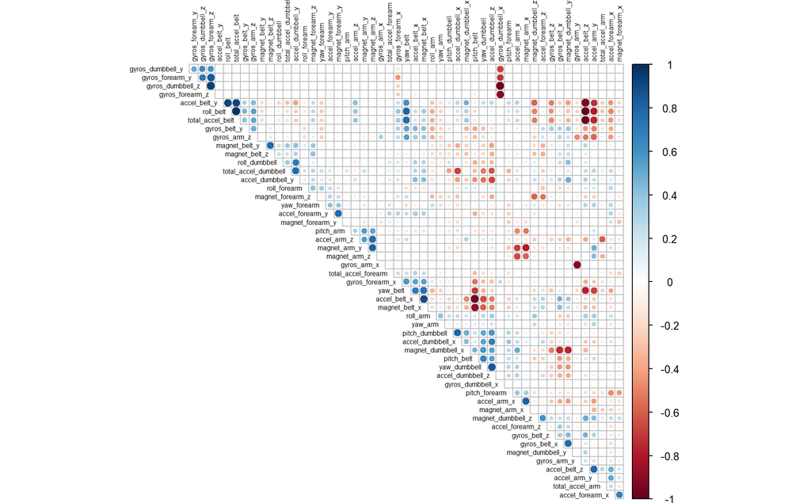

```r
corrplot::corrplot(cor(TrainingDT[,1:52]),  type = "upper", tl.pos = "td",method = "circle", tl.cex = 0.5, tl.col = 'black',order = "hclust", diag = FALSE)
```

Doing the cleaning of variables correlated above 75%

```r
highcorr <- caret::findCorrelation(cor(TrainingDT[,1:52]), cutoff=0.75)
length(highcorr)
```

```
## [1] 21
```

```r
TrainingDT <- TrainingDT[,-highcorr]
TestingDT <- TestingDT[,-highcorr]

dim(TrainingDT)
```

```
## [1] 19622    32
```

## Training and testing DB

To performe this exercise we need to take the training data and split it into testing and training, we will performe three distinct models from the less compute demanding to the highest. The first model that it will we fitted is decision tree algorithm.

```r
trnrows <- as.vector(caret::createDataPartition(TrainingDT$classe,
                                                p = 0.7,
                                                list = F))
training <-  TrainingDT[trnrows,]
testing <- TrainingDT[-trnrows,]

## Control for all the models

control <- caret::trainControl(method = "repeatedcv",
                        number = 5,
                        repeats = 5,
                        summaryFunction = caret::multiClassSummary,
                        classProbs = TRUE)
```

## LM - Decision tree

```r
set.seed(123)
modDT <- caret::train(classe ~ .,
               method = "rpart",
               data = training,
               tuneLength = 50,
               metric = "Accuracy",
               trControl = control)
predDT <- predict(modDT, testing)

caret::confusionMatrix(testing$classe, predDT)
```

```
## Confusion Matrix and Statistics
##
##           Reference
## Prediction    A    B    C    D    E
##          A 1578   47   18    7   24
##          B  122  855   69   58   35
##          C   19   94  872   27   14
##          D   56   41   63  781   23
##          E   24   64   48   30  916
##
## Overall Statistics
##
##                Accuracy : 0.85
##                  95% CI : (0.8406, 0.859)
##     No Information Rate : 0.3057
##     P-Value [Acc > NIR] : < 2.2e-16
##
##                   Kappa : 0.8097
##
##  Mcnemar's Test P-Value : < 2.2e-16
##
## Statistics by Class:
##
##                      Class: A Class: B Class: C Class: D Class: E
## Sensitivity            0.8772   0.7766   0.8150   0.8649   0.9051
## Specificity            0.9765   0.9406   0.9680   0.9633   0.9659
## Pos Pred Value         0.9427   0.7507   0.8499   0.8102   0.8466
## Neg Pred Value         0.9475   0.9482   0.9593   0.9752   0.9800
## Prevalence             0.3057   0.1871   0.1818   0.1534   0.1720
## Detection Rate         0.2681   0.1453   0.1482   0.1327   0.1556
## Detection Prevalence   0.2845   0.1935   0.1743   0.1638   0.1839
## Balanced Accuracy      0.9268   0.8586   0.8915   0.9141   0.9355
```

### Decision tree accuracy

Decision tree has an accuracy 84.9958% with a CI - 95% between 84.058% and 85.899%.

```r
round(caret::confusionMatrix(testing$classe, predDT)$overall, 4)
```

```
##       Accuracy          Kappa  AccuracyLower  AccuracyUpper   AccuracyNull
##         0.8500         0.8097         0.8406         0.8590         0.3057
## AccuracyPValue  McnemarPValue
##         0.0000         0.0000
```

### Visualil decision tree

[figure not shown]

```r
# I shut down the warnings because we will have overplotting
rpart.plot::rpart.plot(modDT$finalModel)
```

## Gradient Boosting Model

```r
set.seed(123)
modGBM <- caret::train(classe~.,
                       training,
                       method = "gbm",
                       trControl = control,
                       verbose = F)
predGBM <- predict(modGBM, testing)
caret::confusionMatrix(testing$classe, predGBM)
```

```
## Confusion Matrix and Statistics
##
##           Reference
## Prediction    A    B    C    D    E
##          A 1643   16    6    7    2
##          B   38 1040   52    1    8
##          C    1   55  947   19    4
##          D    3   10   39  903    9
##          E    8    8   16   17 1033
##
## Overall Statistics
##
##                Accuracy : 0.9458
##                  95% CI : (0.9397, 0.9514)
##     No Information Rate : 0.2877
##     P-Value [Acc > NIR] : < 2.2e-16
##
##                   Kappa : 0.9314
##
##  Mcnemar's Test P-Value : 8.34e-06
##
## Statistics by Class:
##
##                      Class: A Class: B Class: C Class: D Class: E
## Sensitivity            0.9705   0.9212   0.8934   0.9535   0.9782
## Specificity            0.9926   0.9792   0.9836   0.9876   0.9899
## Pos Pred Value         0.9815   0.9131   0.9230   0.9367   0.9547
## Neg Pred Value         0.9881   0.9812   0.9767   0.9911   0.9952
## Prevalence             0.2877   0.1918   0.1801   0.1609   0.1794
## Detection Rate         0.2792   0.1767   0.1609   0.1534   0.1755
## Detection Prevalence   0.2845   0.1935   0.1743   0.1638   0.1839
## Balanced Accuracy      0.9815   0.9502   0.9385   0.9706   0.9840
```

### Gradient Boosting model accuracy

Gradient boosting model has an accuracy 94.5794% with a CI - 95% between 93.970% and 95.144%.

```r
round(caret::confusionMatrix(testing$classe, predGBM)$overall, 4)
```

```
##       Accuracy          Kappa  AccuracyLower  AccuracyUpper   AccuracyNull
##         0.9458         0.9314         0.9397         0.9514         0.2877
## AccuracyPValue  McnemarPValue
##         0.0000         0.0000
```

### GBM Plot

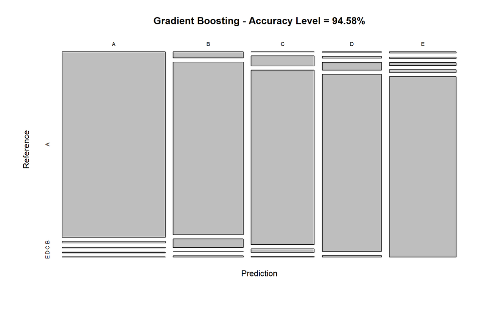

```r
plot(caret::confusionMatrix(testing$classe, predGBM)$table,
     main = paste("Gradient Boosting - Accuracy Level =",
                  scales::percent(caret::confusionMatrix(testing$classe, predGBM)$overall[['Accuracy']],accuracy = 0.01)))
```

## Random forests modeling

```r
cores <- 8
library(doParallel)
cl<- parallel::makePSOCKcluster(cores)
doParallel::registerDoParallel(cl)
modRF <- caret::train(classe ~.,
               method='parRF',
               data=training,
               controRF = control,
               verboseIter = F)

parallel::stopCluster(cl)
predRF <- predict(modRF, testing)
caret::confusionMatrix(testing$classe, predRF)
```

```
## Confusion Matrix and Statistics
##
##           Reference
## Prediction    A    B    C    D    E
##          A 1671    3    0    0    0
##          B    9 1125    4    0    1
##          C    0    8 1012    6    0
##          D    0    0   13  951    0
##          E    0    0    0    1 1081
##
## Overall Statistics
##
##                Accuracy : 0.9924
##                  95% CI : (0.9898, 0.9944)
##     No Information Rate : 0.2855
##     P-Value [Acc > NIR] : < 2.2e-16
##
##                   Kappa : 0.9903
##
##  Mcnemar's Test P-Value : NA
##
## Statistics by Class:
##
##                      Class: A Class: B Class: C Class: D Class: E
## Sensitivity            0.9946   0.9903   0.9835   0.9927   0.9991
## Specificity            0.9993   0.9971   0.9971   0.9974   0.9998
## Pos Pred Value         0.9982   0.9877   0.9864   0.9865   0.9991
## Neg Pred Value         0.9979   0.9977   0.9965   0.9986   0.9998
## Prevalence             0.2855   0.1930   0.1749   0.1628   0.1839
## Detection Rate         0.2839   0.1912   0.1720   0.1616   0.1837
## Detection Prevalence   0.2845   0.1935   0.1743   0.1638   0.1839
## Balanced Accuracy      0.9970   0.9937   0.9903   0.9950   0.9994
```

### Random Forest accuracy

Random Forest has an accuracy 99.2353% with a CI - 95% between 98.978% and 99.442%.

```r
round(caret::confusionMatrix(testing$classe, predGBM)$overall, 4)
```

[output not shown]

### Random Forest Plot

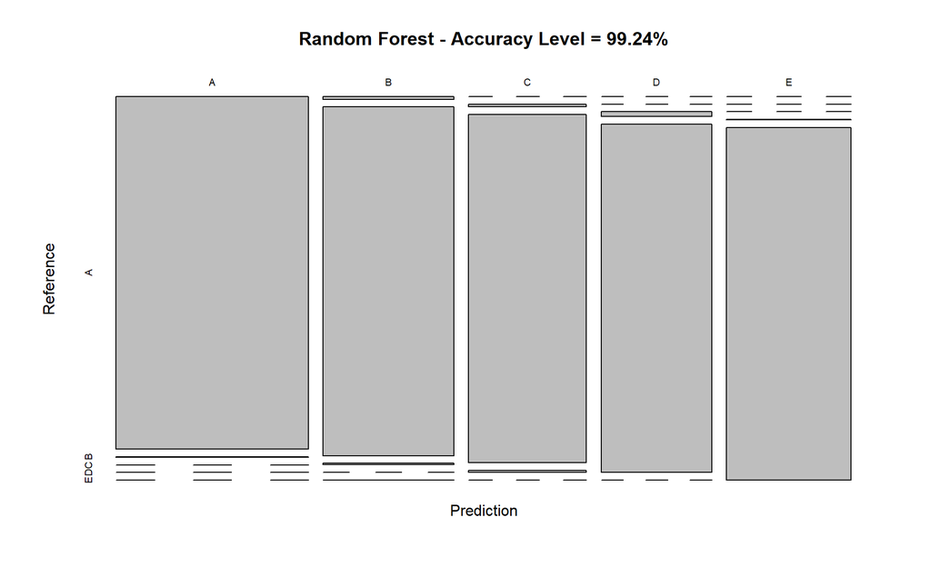

```r
plot(caret::confusionMatrix(testing$classe, predRF)$table,
     main = paste("Random Forest - Accuracy Level =",
                  scales::percent(caret::confusionMatrix(testing$classe, predRF)$overall[['Accuracy']],accuracy = 0.01)))
```

# Prediction

In this step we will use the model with the best accuracy

```r
predict(modRF, TestingDT)
```

```
##  [1] B A B A A E D B A A B C B A E E A B B B
## Levels: A B C D E
```

# Conclusion

We had calculated different models to predict the kind of activity from given variables values and we can compare their accuracy in the following matrix

|  | Decision Tree | Gradient Boosting | Random Forest |
| --- | --- | --- | --- |
| AccuracyLower | 0.841 | 0.940 | 0.990 |
| Accuracy | 0.850 | 0.946 | 0.992 |
| AccuracyUpper | 0.859 | 0.951 | 0.994 |
| Kappa | 0.810 | 0.931 | 0.990 |